# Practica 2

Jose Calatayud Mateu

2024-03-01

```r
library(plyr)
```

```r
library(ggplot2)
library(haven)
library(readxl)
library(readr)
library(tidyverse)
```

# Part 1

## Qüestió 1

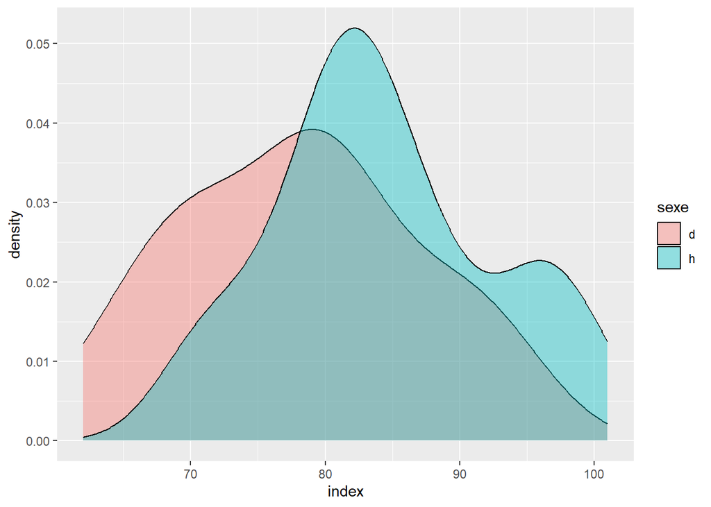

```r
# Importació de les dades i modificacions

dt<- readxl::read_excel("files/dades_ratio_dits_Remostreig_2022-23.xlsx")

dades_plot <- dt[,c("index","sexe")]
dades_plot <- dades_plot[complete.cases(dades_plot),]
ggplot(dades_plot, aes(x=index, fill=sexe)) + geom_density(alpha=0.4)
```

```r
H <- dades_plot[dades_plot$sexe=="h",]$index
D <- dades_plot[dades_plot$sexe=="d",]$index
t.test(H,D)
```

```
##
##  Welch Two Sample t-test
##
## data:  H and D
## t = 2.7161, df = 52.869, p-value = 0.008906
## alternative hypothesis: true difference in means is not equal to 0
## 95 percent confidence interval:
##   1.637735 10.888447
## sample estimates:
## mean of x mean of y
##  84.44828  78.18519
```

```r
rep<-100000
st <- numeric(rep)
cnt <- 0

sttrue <- mean(H)-mean(D)

n1 <- length(H)
n<-nrow(dades_plot)

for (i in 1:rep) {
  remostra <- sample(dades_plot$index, n, replace = F)
  hmostra <- mean(remostra[1:n1])
  dmostra <- mean(remostra[-(1:n1)])
  st[i] <- hmostra-dmostra
  if(abs(st[i]) > abs(sttrue)){ cnt <- cnt +1}
}

p_value <- cnt/rep
p_value
```

```
## [1] 0.00847
```

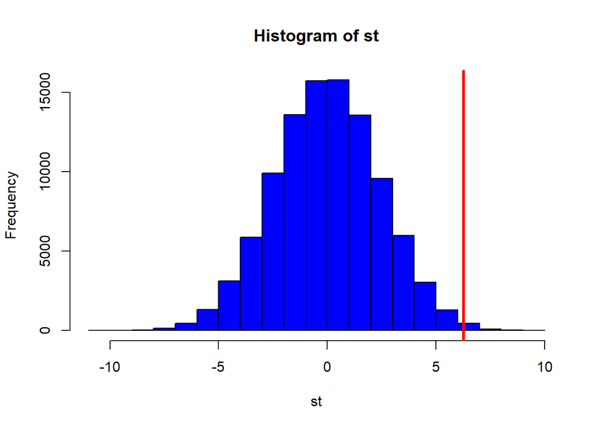

```r
hist(st, col="blue")
abline(v=sttrue, col="red", lwd=3)
```

```r
rep<-100000
st <- numeric(rep)
cnt <- 0

sttrue <- median(H)-median(D)

n1 <- length(H)
n<-nrow(dades_plot)

for (i in 1:rep) {
  remostra <- sample(dades_plot$index, n, replace = F)
  hmostra <- median(remostra[1:n1])
  dmostra <- median(remostra[-(1:n1)])
  st[i] <- hmostra-dmostra
  if(abs(st[i]) > abs(sttrue)){ cnt <- cnt +1}
}

p_value <- cnt/rep
p_value
```

```
## [1] 0.03291
```

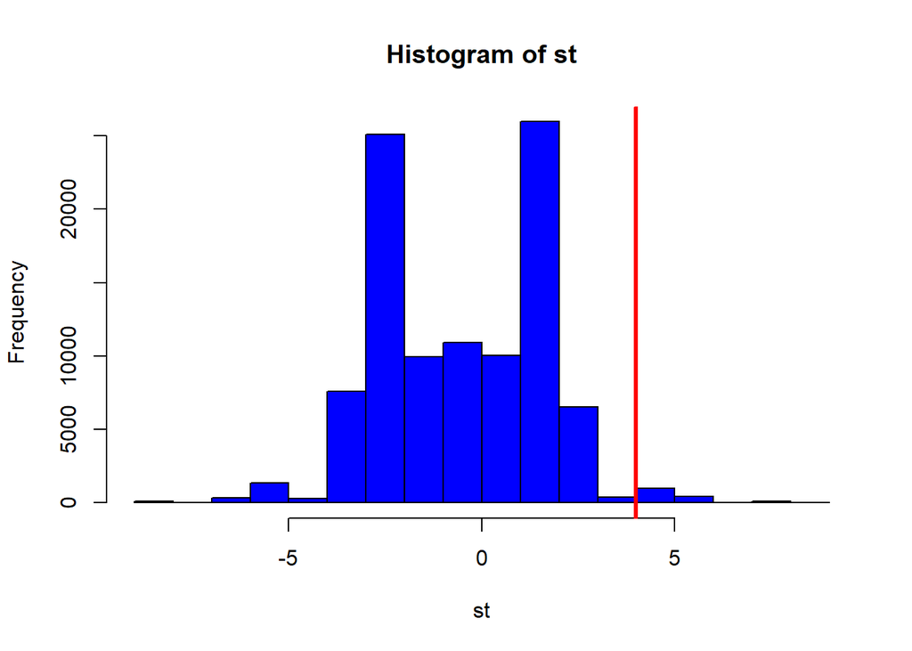

```r
hist(st, col="blue")
abline(v=sttrue, col="red", lwd=3)
```

## Qüestió 2

```r
TRC <- read_delim("C:/Users/jcalatayud/Desktop/Simulacio_i_Remostreig/Practica/files/TRC.csv", delim = "\t")
summary(TRC)
```

```
##       FE_b           FE_12m
##  Min.   : 9.00   Min.   :14.00
##  1st Qu.:21.00   1st Qu.:26.00
##  Median :25.00   Median :31.00
##  Mean   :25.03   Mean   :32.48
##  3rd Qu.:29.25   3rd Qu.:38.25
##  Max.   :35.00   Max.   :69.00
```

```r
before <- TRC$FE_b
after <- TRC$FE_12m
t.test(before,after, paired=TRUE)
```

```
##
##  Paired t-test
##
## data:  before and after
## t = -11.391, df = 183, p-value < 2.2e-16
## alternative hypothesis: true mean difference is not equal to 0
## 95 percent confidence interval:
##  -8.748107 -6.164936
## sample estimates:
## mean difference
##       -7.456522
```

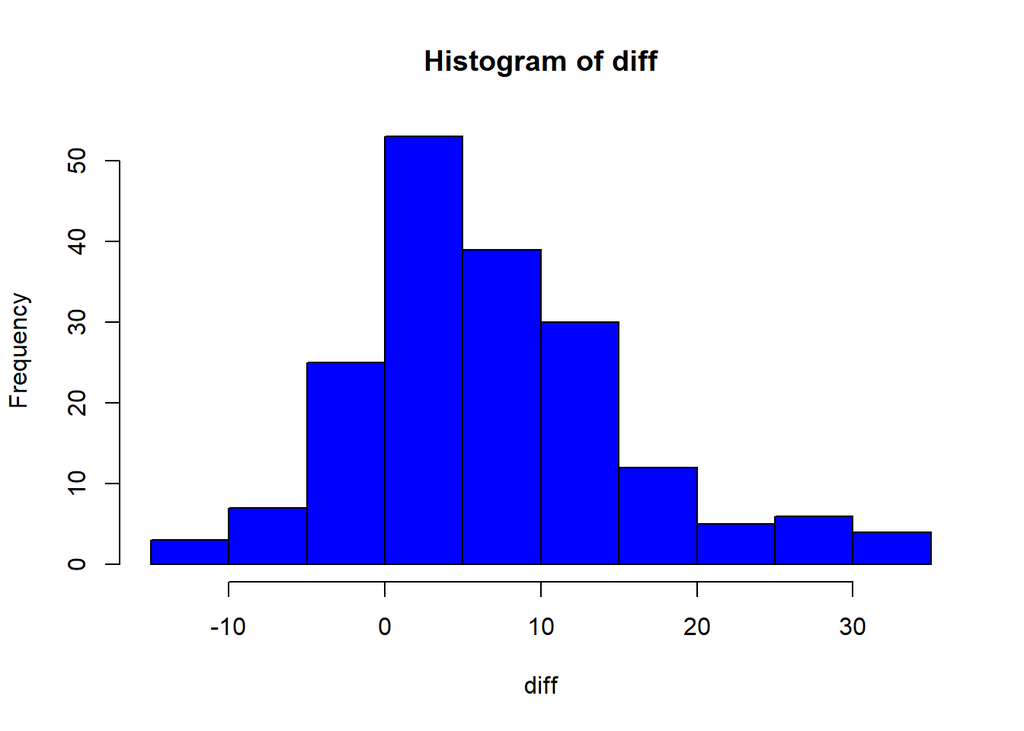

```r
diff <- after-before
hist(diff, col="blue")
```

```r
rep <- 1000
sttrue <- mean(diff)
n<-nrow(TRC)
cnt<-0
st<-numeric(rep)

for (i in 1:rep) {
  remostra <- sample(c(1,-1), n, replace = T)
  st[i] <- mean(diff*remostra)
  if(abs(st[i]) > abs(sttrue)){ cnt <- cnt +1}
}

pvalue <- cnt/rep
pvalue
```

```
## [1] 0
```

Podem dir que, el abans i el després és brutalment significatiu, però no podem afirmar que un es millor que un altre si no tenim un grup CONTROL. Ací hi ha associació, però l’associació NO implica efecte.

La diferència del abans i el després és significativa però NO es pot saber si es pels tractaments o no.

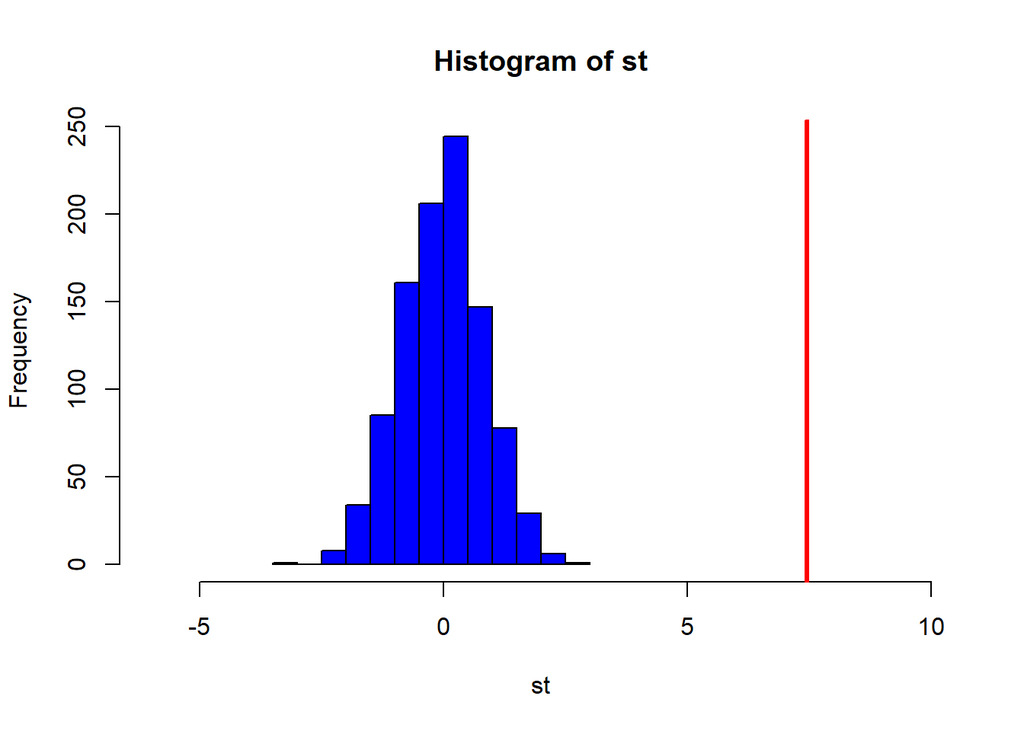

```r
hist(st, col="blue", xlim=c(-6,10))
abline(v=sttrue, col="red", lwd=3)
```

## Qüestió 3

*Assume that during a three-hour period spent outside, a person recorded the temperature, the amount of time they mowed the grass, and their water consumption. The experiment was conducted on 7 randomly selected days during the summer. The data is shown in the table below with the temperature placed in increasing order.*

*1. Plot the data*

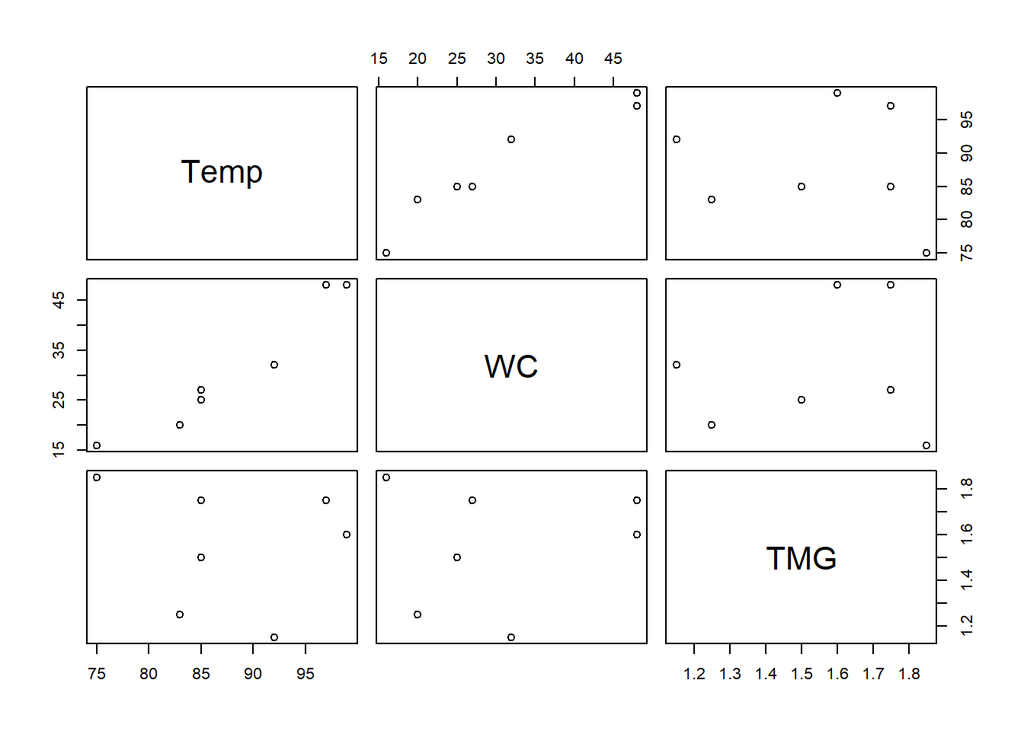

```r
Temp <- c(75,83,85,85,92,97,99)
WC <- c(16,20,25,27,32,48,48)
TMG <- c(1.85,1.25,1.5,1.75,1.15,1.75,1.6)
dades <- data.frame(Temp, WC, TMG)
plot(dades)
```

*2. Predict the Water Consumption as a linear function of the Temperature (T) and the Time mowing the grass (TMG) by means of a multiple regression model. Explore interactions to fit the model. Is the interaction necessary in the model? Why?*

```r
model <- lm(WC~Temp+TMG)
a<-summary(model); a
```

```
##
## Call:
## lm(formula = WC ~ Temp + TMG)
##
## Residuals:
##       1       2       3       4       5       6       7
##  1.0441  0.4642 -0.6935 -1.8264  0.1061  1.0252 -0.1197
##
## Coefficients:
##               Estimate Std. Error t value Pr(>|t|)
## (Intercept) -121.65500    6.54035 -18.601 4.92e-05 ***
## Temp           1.51236    0.06077  24.886 1.55e-05 ***
## TMG           12.53168    1.93302   6.483  0.00292 **
## ---
## Signif. codes:  0 '***' 0.001 '**' 0.01 '*' 0.05 '.' 0.1 ' ' 1
##
## Residual standard error: 1.245 on 4 degrees of freedom
## Multiple R-squared:  0.9937, Adjusted R-squared:  0.9905
## F-statistic: 313.2 on 2 and 4 DF,  p-value: 4.027e-05
```

```r
temptrue <- a$coefficients[2,3]
TMGtrue <- a$coefficients[3,3]

model_interact <- lm(WC~Temp*TMG)
summary(model_interact)
```

```
##
## Call:
## lm(formula = WC ~ Temp * TMG)
##
## Residuals:
##        1        2        3        4        5        6        7
##  0.96174  0.58085 -0.65018 -1.80965 -0.01499  1.08362 -0.15139
##
## Coefficients:
##               Estimate Std. Error t value Pr(>|t|)
## (Intercept) -129.56029   56.02595  -2.313   0.1038
## Temp           1.60298    0.64025   2.504   0.0874 .
## TMG           17.20797   32.91635   0.523   0.6373
## Temp:TMG      -0.05377    0.37759  -0.142   0.8958
## ---
## Signif. codes:  0 '***' 0.001 '**' 0.01 '*' 0.05 '.' 0.1 ' ' 1
##
## Residual standard error: 1.433 on 3 degrees of freedom
## Multiple R-squared:  0.9937, Adjusted R-squared:  0.9874
## F-statistic: 157.7 on 3 and 3 DF,  p-value: 0.0008479
```

La interacció no es necessaria en el model perque NO és significativa. D’acord amb el resultat del plot de l’apartat anterior, sembla no haver-hi cap tipus de relació entre les covariables com per poder tindre en compte la seua interacció. Aloeshores, la introducció d’una intracció no significativa fa que la resta de variables deixen de ser-ho no capturant cap tipus de nova variabilitat.

*3. Write the model and check the model assumptions.*

Model escrit:

$$WC = -121.65 + 1.51 \cdot Temp + 12.53 \cdot TMG$$
Checkejar les suposicions del model (Gauss-Markov):

1. Linealitat i nul·litat
2. Normalitat dels residus
3. Homocedasticitat
4. No autocorrelacionades

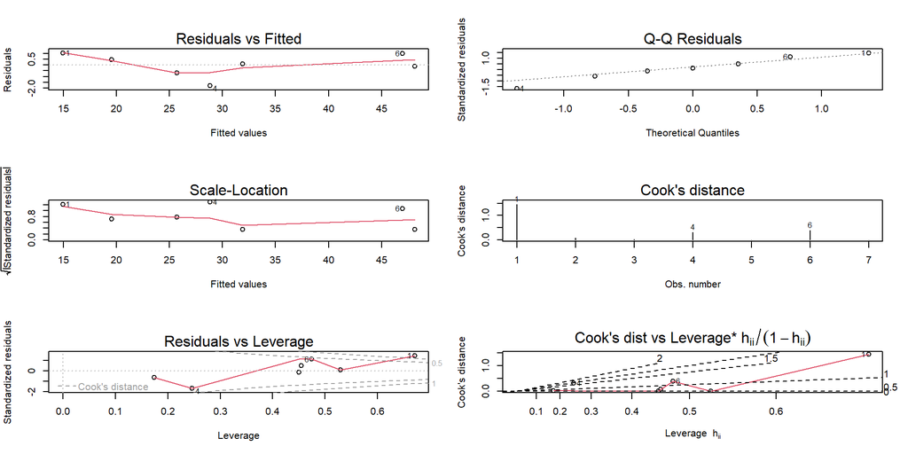

```r
par(mfrow=c(3,2))
plot(model, 1:6)
```

*4. Test the significance of the variables T and TMG using an exact permutation test.*

En el model sense interacció ens indica que les variables Temp i TMG sí son significatives. Ara s’intentarà trobar els mateix resultat utilitzant el permutation test.

El que fem en aquest tipus de contrast es permutar la resposta ja que si la nostra hipòtesi es que els coeficients del model son zero, en dona igual la resposta que tingui perque no hi ha cap tipus d’associació entre la resposta i les covariables.

```r
rep<-100000
ztemp <- numeric(rep)
zTMG <- numeric(rep)

for(i in 1:rep){
  newWC <- sample(WC, size=length(WC), replace=FALSE)
  newmod <- lm(newWC~Temp+TMG)
  a<-summary(newmod)
  ztemp[i] <- a$coefficients[2,3]
  zTMG[i] <- a$coefficients[3,3]
}

pvalueTemp <- sum(abs(ztemp) > abs(temptrue))/rep
pvalueTMG <- sum(abs(zTMG) > abs(TMGtrue))/rep
kableExtra::kable(data.frame(pvalueTemp,pvalueTMG))
```

| pvalueTemp | pvalueTMG |
| --- | --- |
| 0.00077 | 0.00864 |

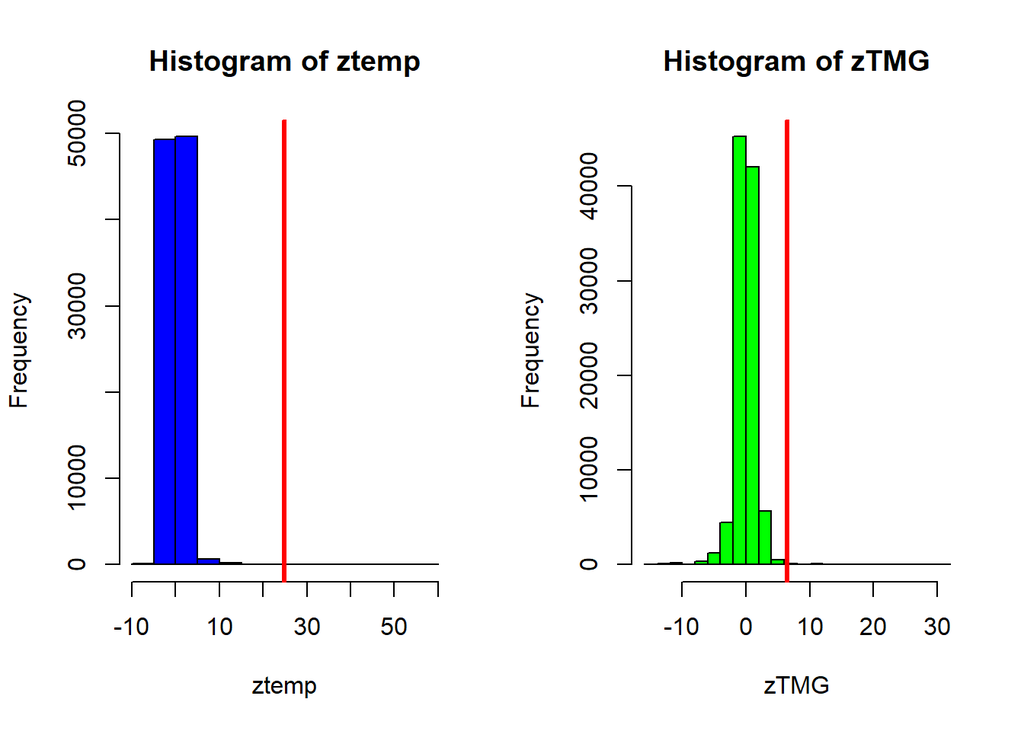

```r
par(mfrow=c(1,2))
hist(ztemp, col='blue'); abline(v=temptrue, col="red", lwd=3)
hist(zTMG, col='green'); abline(v=TMGtrue, col="red", lwd=3)
```

*5. What is the predicted Water Consumption for T=95 and TMG=2? Find a 95$\%$ confidence interval*

```r
pred<-predict(model, newdata = data.frame(Temp=95,TMG=2), interval = c("confidence"), level=0.95);
pred
```

```
##        fit      lwr      upr
## 1 47.08295 43.94917 50.21673
```

El valor de la prdicció donada pel model sense interacció és 47.0829475 amb interval de confiança del $95\%$ de [43.9491653,50.2167297].

## Questió 4

*Give the estimation for the parameters of a linear regression by the method of the least squares* $Y_i = \beta_0 + \beta_1 X_i$.

El objectiu d’aquest apartat és obtindre les estimacions dels paràmetres de regressió pel mètode de Mínims Quadrats. En efecte, aquest mètode està basat en minimitzar el error quadràtic de la diferència entre el valor real i el valor teòric donada per la recta de regressió.

Nosaltres partim de l’objectiu de que podem ajustar una recta de regressió, en funció de covariables, a les observacions de $Y_i$, i.e, $Y_i = \beta_0 + \beta_1 X_i$. Aleshores es miniritzarà el següent error:

$$F=\sum_{i=1}^n e_i^2 = \sum_{i=1}^n (y_i-\beta_0-\beta_1 x_i)^2$$
Amb el objectiu de minimitzar en ment, es calcularan les respectives derivades parcials:

$$\dfrac{\partial F}{\partial \beta_0}= -2 \cdot
\sum_{i=1}^n(y_i-\beta_0-\beta_1 x_i) \\
\dfrac{\partial F}{\partial \beta_0}= -2 \cdot
\sum_{i=1}^n(y_i-\beta_0-\beta_1 x_i) \cdot x_i \\$$
d’on es dedueixen les dues equacions normals:

$$\sum_{i=1}^n(y_i-\beta_0-\beta_1 x_i)=0 \\
\sum_{i=1}^n(y_i-\beta_0-\beta_1 x_i) \cdot x_i =0$$

De la primera equació es dedueix que,

$$\sum_{i=1}^n y_i- n\beta_0-\beta_1 \sum_{i=1}^nx_i = 0 \\
n\bar{y} - n\beta_0 - n\beta_1\bar{x}=0 \\
\bar{y} - \beta_0 - \beta_1\bar{x}=0 \\$$
de la última expressió s’obté que $\beta_0$ en funció de $\beta_1$:

$$\hat{\beta_0} = \bar{Y}- \beta_1\bar{X}$$
Ara, desenvolupant la segona equació normal, i tenint en compte aquest resultat,:

$$\sum_{i=1}^n y_ix_i-\beta_0\sum_{i=1}^n x_i -\beta_1 \sum_{i=1}^n x_i^2
= 0 \\
\sum_{i=1}^n y_ix_i-(\bar{y}- \beta_1\bar{x})\sum_{i=1}^n x_i -\beta_1
\sum_{i=1}^n x_i^2 = 0 \\
\sum_{i=1}^n y_ix_i-\bar{y}\sum_{i=1}^n x_i+ \beta_1\bar{x}\sum_{i=1}^n
x_i -\beta_1 \sum_{i=1}^n x_i^2 = 0 \\
n\bar{xy}-n\bar{x}\bar{y}+ n\beta_1\bar{x}^2 -n\beta_1 \bar{x_i^2} = 0
\\
Cov(X,Y) - \beta_1Var(X)=0$$
Aleshores, es deduiex que:

$$\hat{\beta_1}= \dfrac{Cov(X,Y)}{Var(X)}$$
I aquestes serien les estimacions del coefficients de la recta pel mètode de mínims quadrats ordinari.

## Qüestió 5

*Atrial fibrillation is an abnormal heart rhythm (arrhythmia) characterized by rapid and irregular beating of the atrial chambers of the heart and is associated with an increased risk of heart failure, dementia, and stroke.*

*1. Make a description of the sample and clean the data.*

```r
data <- read_sav("C:/Users/jcalatayud/Desktop/Simulacio_i_Remostreig/Practica/files/ABLACIO_FA_REMOSTREIG.sav")
summary(data)
```

```
##    ID_PACIENT        AGE             SEX             HTA
##  Min.   :  51   Min.   :21.00   Min.   :0.000   Min.   :0.0000
##  1st Qu.: 711   1st Qu.:49.00   1st Qu.:0.000   1st Qu.:0.0000
##  Median : 971   Median :57.00   Median :1.000   Median :0.0000
##  Mean   :1008   Mean   :55.62   Mean   :0.745   Mean   :0.4384
##  3rd Qu.:1393   3rd Qu.:63.00   3rd Qu.:1.000   3rd Qu.:1.0000
##  Max.   :1700   Max.   :77.00   Max.   :1.000   Max.   :1.0000
##    ARRHYTHMIA       AF_TIME         TECHNIQUE       RECURRENCE
##  Min.   :1.000   Min.   :  1.00   Min.   :1.000   Min.   :0.0000
##  1st Qu.:1.000   1st Qu.: 15.00   1st Qu.:1.000   1st Qu.:0.0000
##  Median :1.000   Median : 36.00   Median :1.000   Median :0.0000
##  Mean   :1.415   Mean   : 50.46   Mean   :1.192   Mean   :0.4642
##  3rd Qu.:2.000   3rd Qu.: 60.00   3rd Qu.:1.000   3rd Qu.:1.0000
##  Max.   :2.000   Max.   :468.00   Max.   :2.000   Max.   :1.0000
```

```r
data[,c("SEX","HTA","ARRHYTHMIA", "TECHNIQUE", "RECURRENCE")] <- lapply(data[,c("SEX","HTA","ARRHYTHMIA", "TECHNIQUE", "RECURRENCE")], FUN = factor)

skimr::skim(data)
```

Data summary

| Name | data |
| --- | --- |
| Number of rows | 349 |
| Number of columns | 8 |
| _______________________ |  |
| Column type frequency: |  |
| factor | 5 |
| numeric | 3 |
| ________________________ |  |
| Group variables | None |

**Variable type: factor**

| skim_variable | n_missing | complete_rate | ordered | n_unique | top_counts |
| --- | --- | --- | --- | --- | --- |
| SEX | 0 | 1 | FALSE | 2 | 1: 260, 0: 89 |
| HTA | 0 | 1 | FALSE | 2 | 0: 196, 1: 153 |
| ARRHYTHMIA | 0 | 1 | FALSE | 2 | 1: 204, 2: 145 |
| TECHNIQUE | 0 | 1 | FALSE | 2 | 1: 282, 2: 67 |
| RECURRENCE | 0 | 1 | FALSE | 2 | 0: 187, 1: 162 |

**Variable type: numeric**

| skim_variable | n_missing | complete_rate | mean | sd | p0 | p25 | p50 | p75 | p100 | hist |
| --- | --- | --- | --- | --- | --- | --- | --- | --- | --- | --- |
| ID_PACIENT | 0 | 1 | 1008.32 | 418.65 | 51 | 711 | 971 | 1393 | 1700 | ▂▅▇▆▇ |
| AGE | 0 | 1 | 55.62 | 10.52 | 21 | 49 | 57 | 63 | 77 | ▁▂▆▇▃ |
| AF_TIME | 0 | 1 | 50.46 | 55.47 | 1 | 15 | 36 | 60 | 468 | ▇▁▁▁▁ |

*2. Test the significance of the comparison between techniques and compute the probability of recurrence using an exact permutation test.*

$$H_0: \text{Recurrència i Technique son independents}$$

```r
a<-table(data$RECURRENCE,data$ARRHYTHMIA)
modelchisq <- chisq.test(a); modelchisq
```

```
##
##  Pearson's Chi-squared test with Yates' continuity correction
##
## data:  a
## X-squared = 8.2573, df = 1, p-value = 0.004059
```

```r
rep<-100000
xsquared <- numeric(rep)
xsquaredtrue <- modelchisq$statistic
REC <- data$RECURRENCE
TEC <- data$TECHNIQUE

for(i in 1:rep){
  newREC <- sample(REC, size=length(REC), replace=FALSE)
  a<-table(newREC, TEC)
  newmod <- chisq.test(a)
  xsquared[i] <- newmod$statistic
}

pvalueXsquared <- sum(xsquared > xsquaredtrue)/rep
pvalueXsquared
```

```
## [1] 0.0028
```

En canvi d’utilitzar els test de Xi-quadrat, també s’haguera pogut utilitzar tests com $OR=1$, igualtat de Risk Ratio per cada grup…

# Part 2

## Qüestió 1

El contrast de Hotelling tracta de contrastar la igualtat de la mitjana a un valor però ara la mitjana és un vector de mitjanes.

$$H_0: \mu_1 = \mu_0 \\
\text{d'on } \mu_1=(\mu_{11}, \mu_{12}, ...,\mu_{1n})$$

```r
data(iris)
df<-iris[c(1:10),]
df
```

```
##    Sepal.Length Sepal.Width Petal.Length Petal.Width Species
## 1           5.1         3.5          1.4         0.2  setosa
## 2           4.9         3.0          1.4         0.2  setosa
## 3           4.7         3.2          1.3         0.2  setosa
## 4           4.6         3.1          1.5         0.2  setosa
## 5           5.0         3.6          1.4         0.2  setosa
## 6           5.4         3.9          1.7         0.4  setosa
## 7           4.6         3.4          1.4         0.3  setosa
## 8           5.0         3.4          1.5         0.2  setosa
## 9           4.4         2.9          1.4         0.2  setosa
## 10          4.9         3.1          1.5         0.1  setosa
```

```r
skimr::skim(iris)
```

Data summary

| Name | iris |
| --- | --- |
| Number of rows | 150 |
| Number of columns | 5 |
| _______________________ |  |
| Column type frequency: |  |
| factor | 1 |
| numeric | 4 |
| ________________________ |  |
| Group variables | None |

**Variable type: factor**

| skim_variable | n_missing | complete_rate | ordered | n_unique | top_counts |
| --- | --- | --- | --- | --- | --- |
| Species | 0 | 1 | FALSE | 3 | set: 50, ver: 50, vir: 50 |

**Variable type: numeric**

| skim_variable | n_missing | complete_rate | mean | sd | p0 | p25 | p50 | p75 | p100 | hist |
| --- | --- | --- | --- | --- | --- | --- | --- | --- | --- | --- |
| Sepal.Length | 0 | 1 | 5.84 | 0.83 | 4.3 | 5.1 | 5.80 | 6.4 | 7.9 | ▆▇▇▅▂ |
| Sepal.Width | 0 | 1 | 3.06 | 0.44 | 2.0 | 2.8 | 3.00 | 3.3 | 4.4 | ▁▆▇▂▁ |
| Petal.Length | 0 | 1 | 3.76 | 1.77 | 1.0 | 1.6 | 4.35 | 5.1 | 6.9 | ▇▁▆▇▂ |
| Petal.Width | 0 | 1 | 1.20 | 0.76 | 0.1 | 0.3 | 1.30 | 1.8 | 2.5 | ▇▁▇▅▃ |

```r
summary(iris)
```

```
##   Sepal.Length    Sepal.Width     Petal.Length    Petal.Width
##  Min.   :4.300   Min.   :2.000   Min.   :1.000   Min.   :0.100
##  1st Qu.:5.100   1st Qu.:2.800   1st Qu.:1.600   1st Qu.:0.300
##  Median :5.800   Median :3.000   Median :4.350   Median :1.300
##  Mean   :5.843   Mean   :3.057   Mean   :3.758   Mean   :1.199
##  3rd Qu.:6.400   3rd Qu.:3.300   3rd Qu.:5.100   3rd Qu.:1.800
##  Max.   :7.900   Max.   :4.400   Max.   :6.900   Max.   :2.500
##        Species
##  setosa    :50
##  versicolor:50
##  virginica :50
##
##
##
```

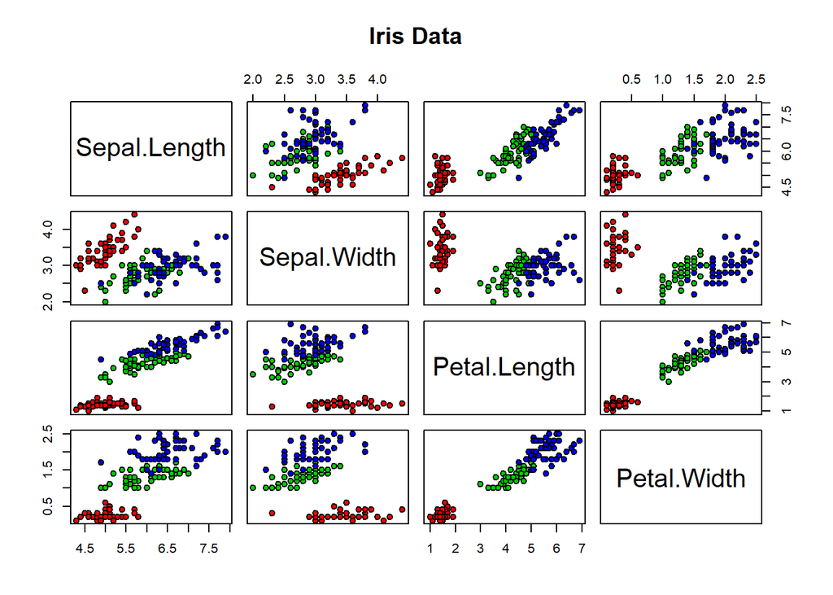

```r
pairs(iris[,1:4], main="Iris Data",
      bg=c("red","green3", "blue")[unclass(iris$Species)], pch=21)
```

```r
# install.packages("GGally")
library(GGally)
```

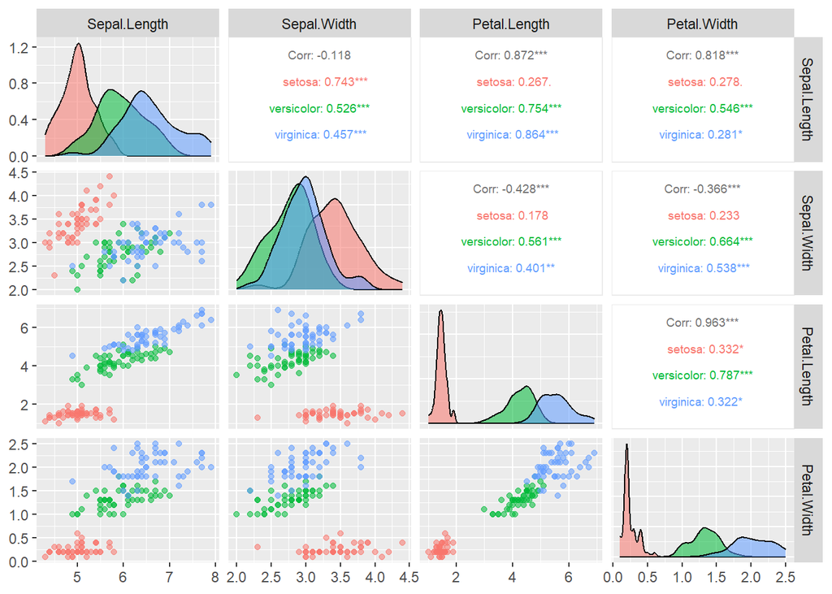

```r
ggpairs(iris, columns = 1:4, aes(color = Species, alpha = 0.5),
        upper = list(continuous = wrap("cor", size = 2.5)))
```

2. *Is a Supervised or Unsupervised problem? Why?*

Es tracta d’un problema supervisat perque coneguem el grup al que pertany cada planta

3. *Construct a function for calculating the Hotelling $T^2$ statistic and compare Iris Setosa and Iris Versicolor (choose only the first 10 observations by group).*

```r
class(split(iris[,1:4], iris$Species))
```

```
## [1] "list"
```

```r
hotelling <- function(data, variables_comparar){ # en la ultima posició sempre estarà la variable a separar
  grups<-data[,ncol(data)]
  data <- data[,-ncol(data)]

  lista <- split(data, grups)
  grup1<- lista[[variables_comparar[1]]][1:10,]
  grup2 <- lista[[variables_comparar[2]]][1:10,]

  n1<- nrow(grup1)
  n2<- nrow(grup2)

  x1 <- apply(grup1, MARGIN=2, FUN=mean)
  x2 <- apply(grup2, MARGIN=2, FUN=mean)

  S1 <- var(grup1)
  S2 <- var(grup2)

  Sp <- ((n1-1)*S1 +(n2-1)*S2)/(n1+n2-2)
  Spinv <- solve(Sp)

  T2 <- (n1*n2*t(x1-x2)%*%Spinv%*%(x1-x2))/(n1+n2)

  m<-ncol(grup1)

  Fisher <- (n1 + n2 - m - 1)*T2*1/((n1 + n2 - 2)*m)
  p_value <- 1-pf(Fisher,m, n1+n2-m-1)

  return(list(T2=as.numeric(T2),
              Fisher=as.numeric(Fisher),
              p_Value=as.numeric(p_value)))
}

hotelling(iris, c("setosa","versicolor"))
```

```
## $T2
## [1] 1173.298
##
## $Fisher
## [1] 244.4372
##
## $p_Value
## [1] 1.854072e-13
```

4. *Perform a permutation test based on the F-statistic and compare the results.*

```r
rep<-10000
data <- iris
dt <- data %>% filter(Species %in% c("setosa", "versicolor"))
Fistrue <- hotelling(iris, c("setosa","versicolor"))$Fisher
Fis <- numeric(rep)

for(i in 1:rep){
  dt$Species <- sample(dt$Species, size=nrow(dt), replace=FALSE)
  x<-hotelling(dt, c("setosa", "versicolor"))
  Fis[i] <- x$Fisher
}

p_valor <- sum(abs(Fis)>Fistrue)/rep
p_valor
```

```
## [1] 0
```

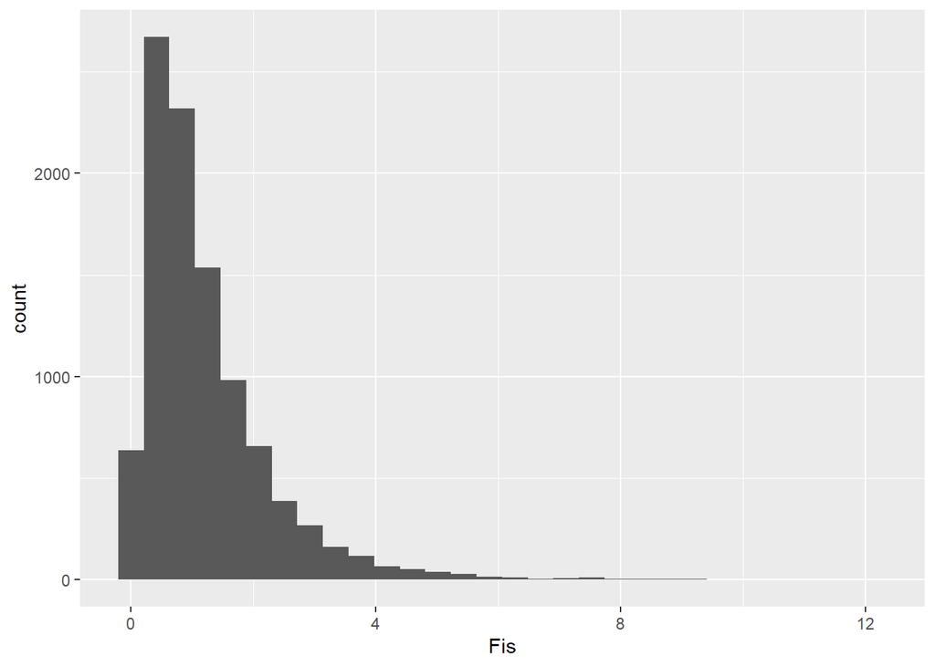

```r
library(ggplot2)

ggplot(data.frame(F=Fis), aes(x =Fis)) +
  geom_histogram()
```

5. *The initial assumptions for the classical Hotelling $T^2$ test are common variance-covariance matrix for the two groups. Do a permutation test for comparing two variance-covariance matrices using the Frobenius norm:*

Agafarem com a estadístic la norma de les diferècies de les matrius de covariàncies i, per tant, si denotem per $\Sigma_i$ a la matriu de variàncies-covariàncies del grup i-èssim s’obté com a hipòtesi nul·la:

$$H_0: ||\Sigma_1-\Sigma_2||_F=0$$

En primer lloc, es crearà una funció que calcule la norma de Frobenius donada una matriu A, en efecte;

```r
traza <- function(A){
  return(sum(diag(A)))
}

frobenius <- function(A){
  sqrt(traza(A*A))
}
```

Encara que es vol fer aquest contrast, no es necessaria la suposició de que les matrius de var-cov son igual al fer el contrast de Hotelling si faig la suposisició de que els grups son iguals i aleatoritze (la suposició de igualtat de grups conté la de igualtat de var-cov).

```r
rep<-10000
data <- iris
dt <- data %>% filter(Species %in% c("setosa", "versicolor"))
x<-dt %>% split(~Species)
var_setosa <- var(x$setosa %>% select(-Species))
var_versicolor <- var(x$versicolor %>% select(-Species))
stadistic_true <- frobenius(var_setosa-var_versicolor)
Stat <- numeric(rep)


for(i in 1:rep){
  dt$Species <- sample(dt$Species, size=nrow(dt), replace=FALSE)
  x<-dt %>% split(~Species)
  var_setosa <- var(x$setosa %>% select(-Species))
  var_versicolor <- var(x$versicolor %>% select(-Species))
  Stat[i] <- frobenius(var_setosa-var_versicolor)
}

p_valor <- sum(abs(Stat)>stadistic_true)/rep
p_valor
```

```
## [1] 0.2844
```

No hi ha evidència per rebutjar la hipòtesi nul·la d’igualtat de matrius de variàncies